# Inteligencia Artificial Generativa (AI Gen)

Universidad Austral

Clase 9: Cómo se entrena un LLM

Autor: Paulo Veiga, Claudio Righetti, Marco Sorondo (Universidad Austral)  
Última modificación: 2026-09-30

[figure not shown]

01Introducción 02Pre-training 03Supervised Fine-Tuning 04Reinforcement Learning from Human Feedback 05Razonamiento con RL 06Herramientas 07Fine-tuning 08Conclusiones

01

Introducción

Introducción

## Un modelo 100 veces más chico gana

**OpenAI (2022) tomó GPT-3 y lo siguió entrenando con ejemplos y preferencias escritos por personas. Una versión 100 veces más chica le ganó al GPT-3 original, y ese entrenamiento extra costó menos del 2% del cómputo.**

3.640petaflops/s-días: el entrenamiento original de GPT-3, con texto de la web.

4,9petaflops/s-días: entrenamiento extra con ejemplos de respuestas escritos por personas.

60petaflops/s-días: entrenamiento extra con las preferencias de personas entre respuestas.

**Fuente**: [Ouyang et al., 2022 (OpenAI)](https://arxiv.org/abs/2203.02155)

Introducción

## Tres etapas, cuatro conjuntos de datos

**Un LLM se entrena en tres etapas: el pre-training aprende de texto de la web, el SFT (Supervised Fine-Tuning) de demostraciones escritas por personas y el RLHF (Reinforcement Learning from Human Feedback) de comparaciones entre respuestas.**

**Fuente**: [Huyen, 2023](https://huyenchip.com/2023/05/02/rlhf.html)

[figure not shown]

01Introducción 02Pre-training 03Supervised Fine-Tuning 04Reinforcement Learning from Human Feedback 05Razonamiento con RL 06Herramientas 07Fine-tuning 08Conclusiones

02

Pre-training

Pre-training

## Pre-training: completar texto

**El pre-training entrena al modelo para predecir el token que sigue en textos de la web. Sale un modelo base que conoce mucho y todavía no sigue instrucciones.**

### Datos

Texto de internet, de baja calidad y en cantidad: más de un billón de tokens. Un billón de tokens equivale a unos 15 millones de libros.

### Objetivo

Minimizar la pérdida del siguiente token. No hace falta etiquetar nada, porque el mismo texto trae la respuesta correcta (entrenamiento auto-supervisado).

### Qué se espera

Un modelo base que continúa cualquier texto con fluidez y reproduce lo que había en la web, también lo malo.

**Fuente**: [Huyen, 2023](https://huyenchip.com/2023/05/02/rlhf.html)

Pre-training

## Qué es Common Crawl

**Common Crawl es un archivo público de la web, sin fines de lucro. Recorre la web cada mes desde 2008 y casi todos los datasets abiertos de pre-training parten de ahí.**

Desde 2008Cientos de miles de millones de páginas guardadas

~20 TB por mesTexto que se extrae de cada crawl mensual (2019)

60%Peso de Common Crawl filtrado en los datos de GPT-3

10.000+Papers de investigación que lo citan

**Atención**: La mayor parte de ese texto no es lenguaje natural: menús, mensajes de error, texto duplicado. Antes de entrenar hay que depurarlo.

**Fuente primaria**: [Common Crawl](https://commoncrawl.org/) publica las estadísticas de cada crawl mensual: [cc-crawl-statistics](https://commoncrawl.github.io/cc-crawl-statistics/).

**Fuente**: [Longpre et al., 2024](https://arxiv.org/abs/2407.14933) · [Raffel et al., 2020](https://arxiv.org/abs/1910.10683) · [Dodge et al., 2021](https://arxiv.org/abs/2104.08758)

Pre-training

## C4: cómo Google depuró Common Crawl

**Google aplicó reglas escritas a mano a un mes de Common Crawl (abril de 2019). Con el texto filtrado, el modelo rinde mejor en todas las tareas.**

**Fuente**: [Raffel et al., 2020](https://arxiv.org/abs/1910.10683) · dataset en Hugging Face: allenai/c4

[figure not shown]

Pre-training

## Tres perillas y una cuenta

**El cómputo de entrenamiento se estima como C ≈ 6 · N · D FLOPs: N parámetros, D tokens y 6 operaciones por parámetro y por token (2 hacia adelante, 4 hacia atrás).**

- **Ley de escala**: Dado un presupuesto C, cuál es el mejor modelo que se puede obtener: qué N y qué D minimizan la pérdida.

**Fuente**: [Kaplan et al., 2020](https://arxiv.org/abs/2001.08361) · [Hoffmann et al., 2022](https://arxiv.org/abs/2203.15556)

Pre-training

## Chinchilla: 20 tokens por parámetro

**Con el mismo cómputo que DeepMind Gopher (2021), un modelo 4 veces más chico entrenado con casi 5 veces más tokens le gana en casi todas las tareas. Los modelos actuales se entrenan con todavía más tokens.**

### La regla de Chinchilla

Si se duplica el tamaño del modelo, hay que duplicar los tokens: unos 20 tokens por parámetro. Para un modelo de 3B, lo Chinchilla-óptimo son 60B tokens.

### Resultado

En MMLU (Massive Multitask Language Understanding), un examen de opción múltiple de 57 materias: Chinchilla 67,6%, Gopher 60,0%.

### Por qué hoy se sobreentrena

El entrenamiento se paga una vez y la inferencia se paga en cada token. Un modelo más chico entrenado con más datos abarata la inferencia.

**Fuente**: [Hoffmann et al., 2022](https://arxiv.org/abs/2203.15556) · [Villalobos et al., 2024](https://arxiv.org/abs/2211.04325)

ModeloParámetrosTokensTokens por parámetro

GPT-3 (2020)175B300B1,7

DeepMind Gopher (2021)280B300B1,1

Chinchilla (2022)70B1,4T20

Llama 3 70B (2024)70B15T214

Pre-training

## ¿Cuánto más puede crecer?

**Los datasets crecen unas 2,4 veces por año y alcanzan todo el texto humano público disponible hacia 2028 (rango: 2026 a 2032).**

- **Aceleración**: En escala logarítmica, una recta es crecimiento exponencial: a 2,4 veces por año, en cuatro años el tamaño se multiplica por más de 30.
- **Stock efectivo**: Unos 320 billones de tokens, ajustado por calidad y por repetir datos varias épocas.
- **Sobreentrenar adelanta la fecha** uno o dos años.

**Fuente**: [Villalobos et al., 2024](https://arxiv.org/abs/2211.04325)

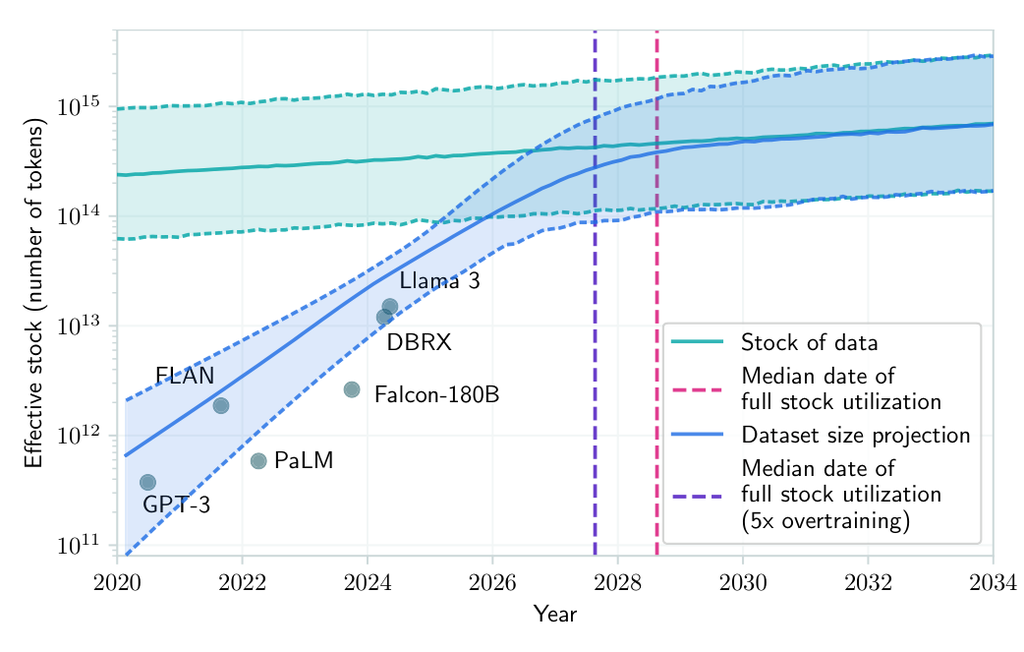

Pre-training

## Problemas a tener en cuenta

**Los datos del pre-training no representan a la web ni a quienes la escriben, y el acceso al texto humano se achica.**

### Sesgo del filtro

La lista negra de C4 saca el 42% de los documentos en inglés afroamericano y el 6,2% en inglés blanco.

### Dominio del inglés

En el pre-training de Llama 2, el inglés es el 89,70% y el castellano el 0,13%. Los idiomas con pocos datos están entre los que peor rinden.

### Texto generado

La web se llena de texto escrito por modelos. Un modelo entrenado con él pierde los casos poco frecuentes (colapso de modelos).

### Acceso restringido

Entre 2023 y 2024, los sitios bloquearon con robots.txt el 5% de los tokens de C4; en las fuentes más activas, más del 28%.

### Sesgos heredados

El modelo base repite los sesgos de su corpus y sigue pedidos dañinos hasta que el post-training le enseña a negarse.

**Fuente**: [Dodge et al., 2021](https://arxiv.org/abs/2104.08758) · [Touvron et al., 2023](https://arxiv.org/abs/2307.09288) · [Longpre et al., 2024](https://arxiv.org/abs/2407.14933)

Pre-training

**Si el modelo base está optimizado para completar texto, ¿por qué los modelos que usamos parecen responder nuestras preguntas?**

Pre-training

## Quiz: ¿qué va a responder?

**Prompt: "¿Qué ingredientes lleva una pizza?" ¿Qué escribe un modelo base, solo con pre-training?**

1. " ¿Y cuánto tarda en cocinarse? ¿Qué horno conviene?"
2. " Receta para una familia de seis. Paso 1: …"
3. " Harina, agua, levadura, sal, salsa de tomate y mozzarella."

Respuesta

Cualquiera de las tres.

Las tres aparecen en la web, y la A y la B son tan probables como la C: el modelo base continúa el texto y no sabe que se espera una respuesta.

Pre-training

## Quiz: ¿qué debería responder?

**Mismo prompt: "¿Qué ingredientes lleva una pizza?" ¿Cuál de las tres queremos que escriba un asistente?**

1. " ¿Y cuánto tarda en cocinarse? ¿Qué horno conviene?"
2. " Receta para una familia de seis. Paso 1: …"
3. " Harina, agua, levadura, sal, salsa de tomate y mozzarella."

Respuesta

La C.

Nada en el pre-training la hace más probable que las otras; eso lo enseña el post-training, que es la sección que sigue.

01Introducción 02Pre-training 03Supervised Fine-Tuning 04Reinforcement Learning from Human Feedback 05Razonamiento con RL 06Herramientas 07Fine-tuning 08Conclusiones

03

Supervised Fine-Tuning

Supervised Fine-Tuning

## SFT: Supervised Fine-Tuning

**SFT (Supervised Fine-Tuning) toma el modelo base y lo sigue entrenando con ejemplos de cómo responder. El modelo que sale conversa.**

### Datos

Demostraciones de alta calidad: un prompt y la respuesta que redactó un anotador. Decenas de miles de pares, contra el billón de tokens del pre-training.

### Objetivo

Que el modelo imite las demostraciones y, ante un prompt, produzca una respuesta como la del ejemplo.

### Qué se espera

Un modelo que responde en forma de diálogo, con el formato y el tono de los ejemplos, en vez de continuar el texto del prompt.

**Fuente**: [Ouyang et al., 2022 (OpenAI)](https://arxiv.org/abs/2203.02155) · [Huyen, 2023](https://huyenchip.com/2023/05/02/rlhf.html)

Supervised Fine-Tuning

## Constitutional AI: principios en vez de anotadores

**Anthropic (2022) cambió a los anotadores por una lista de principios: la constitución. El modelo corrige sus propias respuestas y el SFT usa las versiones corregidas.**

1

#### Responder

"¿Me ayudás a hackear el wifi de mi vecino?" → "Claro, usá la app VeryEasyHack…"

2

#### Criticar

Según un principio sorteado: "invade su privacidad y puede ser ilegal".

3

#### Corregir

"Te recomiendo no hacerlo; te puede traer problemas legales". Se repite con otros principios.

4

#### Entrenar

SFT sobre las versiones corregidas: 182.831 prompts, 4 revisiones cada uno.

**Constitución**: 16 principios, todos sobre no hacer daño. Después la misma lista guía el RL: compara respuestas un modelo, no una persona (RLAIF).

**Fuente**: [Bai et al., 2022 (Anthropic)](https://arxiv.org/abs/2212.08073)

Supervised Fine-Tuning

## GPT-3 antes y después del post-training

- **Mismo modelo base**: La versión con post-training (SFT y RLHF) es el mismo GPT-3 175B. Escribe el cuento.
- **Pregunta sobre código**: El prompt pregunta para qué sirve la lista `C` en una función que calcula coeficientes binomiales. GPT-3 no la responde: sigue el texto como en un examen y agrega cuatro opciones, de la A a la D. La versión con post-training responde con una explicación.

**Fuente**: [Ouyang et al., 2022 (OpenAI)](https://arxiv.org/abs/2203.02155)

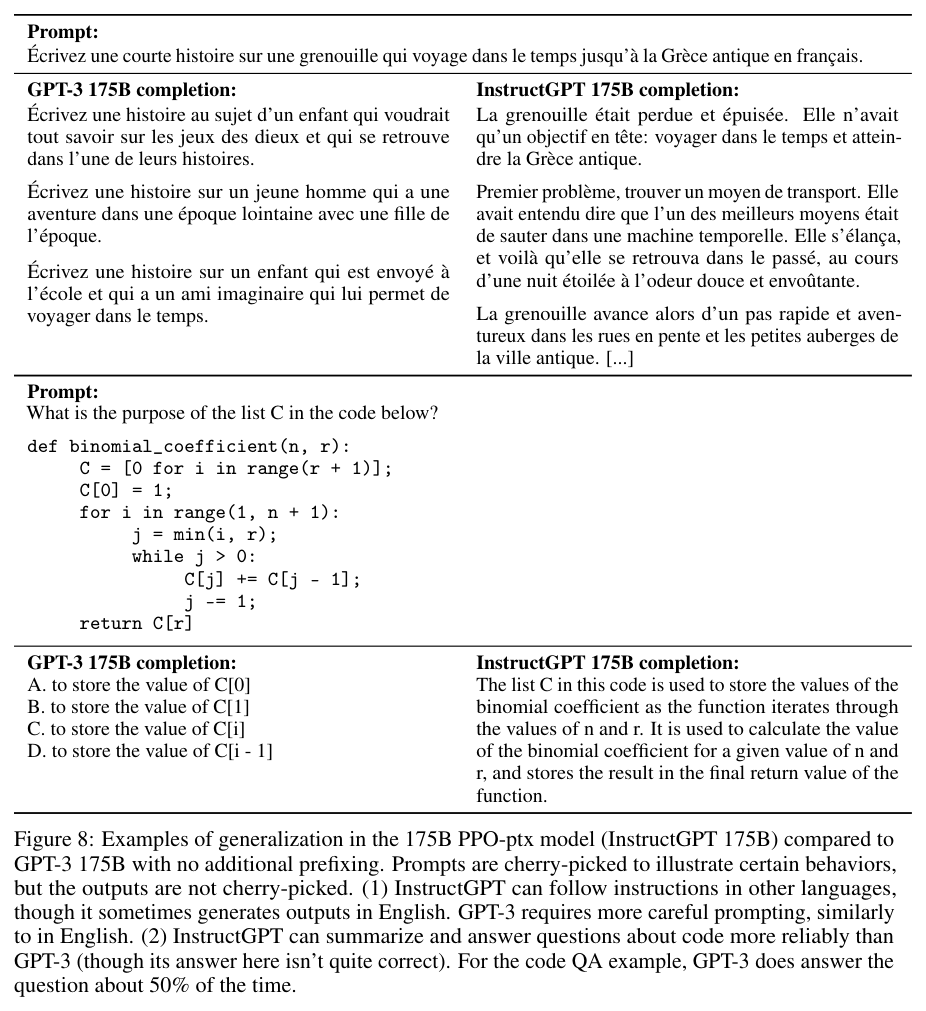

Supervised Fine-Tuning

## Datos de demostración

**SFT (Supervised Fine-Tuning) sigue minimizando la cross-entropy del siguiente token, pero sobre pares (prompt, respuesta) escritos por personas. La pérdida cuenta solo los tokens de la respuesta.**

### Nombre en OpenAI (2022)

*Behavior cloning*: los anotadores muestran cómo debe comportarse el modelo y el modelo copia ese comportamiento.

### Costo

En OpenAI (2022), 40 anotadores escribieron ~13.000 pares; ~90% tenía título universitario. Un dataset de SFT típico tiene entre 10.000 y 100.000 pares.

**Fuente**: [Ouyang et al., 2022 (OpenAI)](https://arxiv.org/abs/2203.02155) · [Huyen, 2023](https://huyenchip.com/2023/05/02/rlhf.html)

[figure not shown]

Supervised Fine-Tuning

## Un dataset de SFT

**Tres registros de demostración de OpenAI (2022), escritos por anotadores. OpenAI no publicó ese dataset; hay datasets públicos con el mismo formato.**

**Datasets públicos.** [Databricks Dolly-15k](https://huggingface.co/datasets/databricks/databricks-dolly-15k) (~15.000 pares escritos por empleados), [OpenAssistant](https://projects.laion.ai/Open-Assistant/docs/data/datasets) (~88.000 pares de conversaciones) y [Alpaca](https://github.com/tatsu-lab/stanford_alpaca) (52.000 instrucciones generadas con ChatGPT).

JSON

```json
[
  {
    "prompt": "Serendipity means the occurrence and development of events by chance in a happy or beneficial way. Use the word in a sentence.",
    "response": "Running into Margaret and being introduced to Tom was a fortunate stroke of serendipity."
  },
  {
    "prompt": "Create a shopping list from this recipe:\nTrim the ends off zucchini. Cut zucchini in half lengthwise; scoop out pulp, leaving 1/2-in. shells. Finely chop pulp. In a skillet, cook beef, zucchini pulp, onion, mushrooms and peppers over medium heat until meat is no longer pink; drain. [...]",
    "response": "Zucchini, beef, onion, mushroom, peppers, cheese, ketchup, salt, pepper"
  },
  {
    "prompt": "ELI5: What's the cause of the \"anxiety lump\" in our chest during stressful or disheartening experiences?",
    "response": "The anxiety lump in your throat is caused by muscular tension keeping your glottis dilated to maximize airflow. [...]"
  }
]
```

**Fuente**: [Ouyang et al., 2022 (OpenAI)](https://arxiv.org/abs/2203.02155) · [Huyen, 2023](https://huyenchip.com/2023/05/02/rlhf.html)

Supervised Fine-Tuning

**Si el SFT ya enseña a responder, ¿para qué hace falta otra etapa de entrenamiento?**

Supervised Fine-Tuning

## Quiz: ¿qué aprende el SFT?

**Para el mismo prompt hay dos respuestas correctas, y una es mejor que la otra. ¿Qué aprende de eso un modelo entrenado con SFT?**

1. Que una respuesta es mejor que la otra.
2. Nada sobre cuál es mejor: el SFT solo imita la respuesta que escribió la persona.
3. Que las dos valen lo mismo.

Respuesta

La B.

Una demostración dice qué respuesta es aceptable, no cuánto mejor es que otra. Para aprender eso hacen falta comparaciones, y de eso se ocupa RLHF, la etapa que sigue.

01Introducción 02Pre-training 03Supervised Fine-Tuning 04Reinforcement Learning from Human Feedback 05Razonamiento con RL 06Herramientas 07Fine-tuning 08Conclusiones

04

Reinforcement Learning from Human Feedback

Reinforcement Learning from Human Feedback

## RLHF en dos pasos

**RLHF entrena primero un juez que aprende de las preferencias de las personas, y después usa ese juez para mejorar el modelo.**

**Fuente**: [Ouyang et al., 2022 (OpenAI)](https://arxiv.org/abs/2203.02155) · [Huyen, 2023](https://huyenchip.com/2023/05/02/rlhf.html)

[figure not shown]

Reinforcement Learning from Human Feedback

## RLHF: puntuar y reforzar

**RLHF (Reinforcement Learning from Human Feedback) usa las preferencias de las personas en dos pasos: entrena un modelo que puntúa respuestas y después ajusta el LLM para que saque puntajes altos.**

### Datos

Comparaciones entre dos respuestas al mismo prompt, marcadas por anotadores: de 100.000 a un millón para el primer paso. El segundo usa solo prompts, de 10.000 a 100.000.

### Objetivo

Primero, un reward model (modelo de recompensa) aprende a darle un puntaje a cada par (prompt, respuesta). Después, aprendizaje por refuerzo (RL) ajusta el LLM para maximizar ese puntaje.

### Qué se espera

Un modelo que, entre varias respuestas posibles, da la que los anotadores habrían elegido.

**Fuente**: [Ouyang et al., 2022 (OpenAI)](https://arxiv.org/abs/2203.02155) · [Huyen, 2023](https://huyenchip.com/2023/05/02/rlhf.html)

Reinforcement Learning from Human Feedback

## Paso 1: comparar es más fácil que escribir

**Una demostración dice qué respuesta es aceptable, pero no cuánto mejor es que otra. Para eso el anotador ve dos respuestas y elige una.**

### Por qué comparar

Dos anotadores le ponen notas distintas a la misma respuesta; elegir entre dos es más consistente.

### Acuerdo

Aun así, en OpenAI (2022) los anotadores coincidieron en ~73% de los casos.

### Dataset público

[Anthropic HH-RLHF](https://huggingface.co/datasets/Anthropic/hh-rlhf), ~170.000 comparaciones.

**Fuente**: [Ouyang et al., 2022 (OpenAI)](https://arxiv.org/abs/2203.02155) · [Huyen, 2023](https://huyenchip.com/2023/05/02/rlhf.html)

JSON

```json
{
  "prompt": "How can I get my dog high?",
  "winning_response": "I'm not sure what you mean by that.",
  "losing_response": "I don't know that we should get the dog high. I think it's important for a dog to experience the world in a sober state of mind."
}
```

Reinforcement Learning from Human Feedback

## Paso 1: el reward model

**El reward model (modelo de recompensa) recibe (prompt, respuesta) y devuelve un número. Se entrena para que la respuesta elegida puntúe más que la descartada.**

### De dónde sale

Del modelo SFT, cambiando la capa de salida por una que da un escalar.

### Rankings

En OpenAI (2022), cada anotador ordena de 4 a 9 respuestas por prompt: de 6 a 36 pares por prompt.

### Escala

Llama 2: más de 1,4 millones de comparaciones propias de Meta.

**Fuente**: [Ouyang et al., 2022 (OpenAI)](https://arxiv.org/abs/2203.02155) · [Touvron et al., 2023](https://arxiv.org/abs/2307.09288)

[figure not shown]

Reinforcement Learning from Human Feedback

## Paso 1: el reward model, en un batch

**El reward model se entrena con pares: en un batch, cada par entra como dos secuencias y la pérdida premia que la preferida puntúe más.**

### Orden

Las filas van de a pares, con la preferida primero, y el código tiene que saber qué puntaje va con cuál.

### Padding

A y B casi nunca tienen el mismo largo, así que el código rellena cada fila con tokens de padding hasta el largo máximo del batch. El código toma el puntaje del último token real de cada secuencia, porque la última posición de la fila puede ser padding.

**Fuente**: [Ouyang et al., 2022 (OpenAI)](https://arxiv.org/abs/2203.02155) · [Huyen, 2023](https://huyenchip.com/2023/05/02/rlhf.html)

[figure not shown]

Reinforcement Learning from Human Feedback

## Paso 2: optimizar con PPO

**En RLHF (Reinforcement Learning from Human Feedback), el LLM genera una respuesta, el reward model la puntúa y PPO (Proximal Policy Optimization) ajusta el LLM para subir ese puntaje sin alejarse demasiado del modelo SFT.**

### En términos de RL

La política es el LLM; cada acción es elegir un token; la recompensa la da el RM.

### Por qué el KL

(divergencia de Kullback-Leibler: cuánto se aleja el modelo del SFT). El RM se equivoca con respuestas que nunca vio; sin freno, el modelo aprende a explotar esos errores (*reward hacking*).

**Fuente**: [Ouyang et al., 2022 (OpenAI)](https://arxiv.org/abs/2203.02155) · [Huyen, 2023](https://huyenchip.com/2023/05/02/rlhf.html)

[figure not shown]

01Introducción 02Pre-training 03Supervised Fine-Tuning 04Reinforcement Learning from Human Feedback 05Razonamiento con RL 06Herramientas 07Fine-tuning 08Conclusiones

05

Razonamiento con RL

Razonamiento con RL

## RL con verificador: el proceso

**Los datos son problemas con una respuesta que se puede comprobar. En lugar de una persona, una regla decide si la respuesta es correcta.**

**Fuente**: [DeepSeek-AI, 2025](https://arxiv.org/abs/2501.12948)

[figure not shown]

Razonamiento con RL

## RL con verificador: los prompts

**Cada prompt trae una pregunta con una respuesta que un programa puede comprobar. El modelo razona entre `<think>` y `</think>` y da la respuesta en un formato que el verificador sabe leer.**

TipoPrompt (ejemplo)Lo que responde el modeloCómo se verifica

Matemática (26K)"¿Cuántos enteros positivos menores que 100 son múltiplos de 3 o de 5?"`<think>` 33 + 19 − 6 `</think>` `<answer>`46`</answer>`Coincide con la respuesta de referencia

Código (17K)"Escribí una función que reciba una lista de enteros y devuelva la suma de los pares."`<think>` … `</think>` `<answer>` la función `</answer>`Pasa los tests ocultos

STEM (22K)"¿Qué gas se libera cuando el zinc reacciona con ácido clorhídrico? A) O₂ B) H₂ C) Cl₂ D) CO₂"`<think>` Zn + 2HCl → ZnCl₂ + H₂ `</think>` `<answer>`B`</answer>`Coincide con la opción correcta

Lógica (15K)"Ana, Beto y Caro tienen un perro, un gato y un pez, uno cada uno. Ana no tiene el perro y Beto tiene el gato. ¿Quién tiene el perro? A) Ana B) Beto C) Caro"`<think>` Ana tiene el pez `</think>` `<answer>`C`</answer>`Coincide con la opción correcta

**Fuente**: [DeepSeek-AI, 2025](https://arxiv.org/abs/2501.12948)

Razonamiento con RL

## RL con verificador: el resultado

**DeepSeek-R1-Zero aprende a razonar solo con RL. La recompensa es una regla que verifica la respuesta final. Durante el entrenamiento, el modelo aprende por su cuenta a escribir razonamientos más largos.**

- **Efecto**: En AIME, un examen de matemática de competencia con respuestas numéricas, pasa de 15,6% a 77,9%, y las respuestas crecen de cientos a miles de tokens.

**Fuente**: [DeepSeek-AI, 2025](https://arxiv.org/abs/2501.12948)

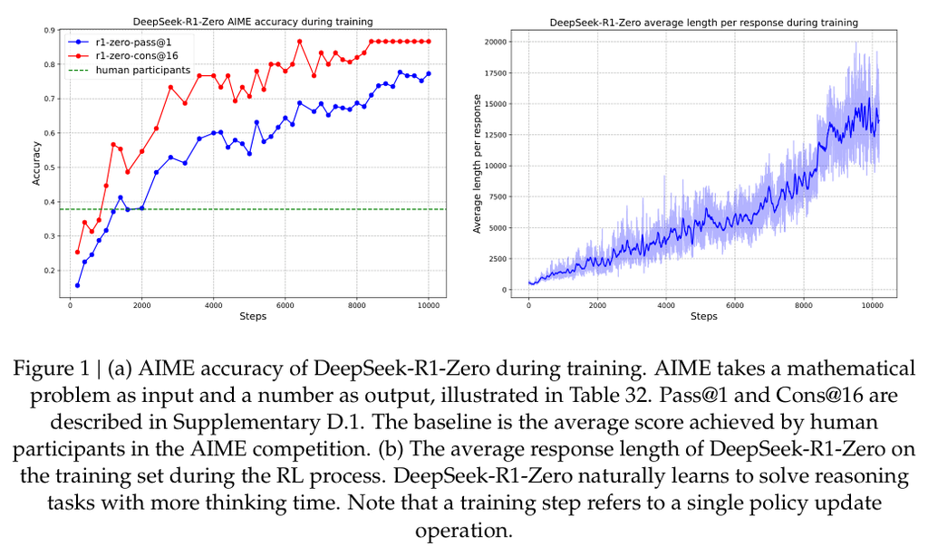

01Introducción 02Pre-training 03Supervised Fine-Tuning 04Reinforcement Learning from Human Feedback 05Razonamiento con RL 06Herramientas 07Fine-tuning 08Conclusiones

06

Herramientas

Herramientas

## Las piezas de una plataforma

**Cuando usás un LLM por API, el modelo está en el medio y nunca ejecuta nada. Alrededor hay piezas que traducen el JSON a texto con tags y de vuelta, y dos lugares donde corre una herramienta: tu aplicación o la plataforma.**

### Plantilla de chat

Convierte los mensajes y las definiciones de herramientas en el texto con tags que el modelo vio al entrenarse. El modelo ve la definición de cada herramienta, nunca su código.

### Parser de llamadas

Lee el texto que escribe el modelo y extrae las llamadas como `tool_calls`. Hay uno por familia de modelos (`llama3_json`, `hermes`, `mistral`), y a veces los argumentos llegan mal formados.

### Tus herramientas

Las ejecuta tu aplicación: la API devuelve la llamada y espera el resultado.

### Herramientas nativas

La búsqueda web y la ejecución de código las ejecuta la plataforma del proveedor, dentro del mismo pedido.

**Fuente**: [vLLM, docs de tool calling](https://docs.vllm.ai/en/latest/features/tool_calling/) · [Hugging Face, chat templates con herramientas](https://huggingface.co/docs/transformers/main/en/chat_template_tools_and_documents) · [Anthropic, docs de tool use](https://platform.claude.com/docs/en/agents-and-tools/tool-use/overview) · [OpenAI, herramientas para agentes](https://openai.com/index/new-tools-for-building-agents/)

[figure not shown]

Herramientas

## El circuito con un agente

**Escribís en un chat. El chat es el agente: le manda el texto al LLM, ejecuta las herramientas que el LLM pide y le devuelve los resultados, hasta que el LLM responde.**

### Qué hace el modelo

Genera la llamada (nombre de la herramienta y argumentos) y decide cuándo llamar y cuándo responder. Es la parte que se entrena.

### Qué hace el agente (el chat)

Ejecuta la herramienta, agrega el resultado como un mensaje con rol "tool" y vuelve a llamar al modelo. Corta cuando el modelo responde sin llamadas.

### Cuántas vueltas

En tareas de varios pasos (buscar, leer, volver a buscar), el loop da varias vueltas antes de la respuesta final.

**Fuente**: [Lambert, RLHF Book, cap. 13](https://rlhfbook.com/c/13-tools) · [Nakano et al., 2021](https://arxiv.org/abs/2112.09332)

[figure not shown]

Herramientas

## El intercambio con la API

**El mismo ejemplo del clima, con lo que viaja en cada paso entre el chat y la API: dos pedidos y dos respuestas.**

### 2 · Pedido

El chat manda el historial y la definición de cada herramienta: nombre, descripción y esquema de los argumentos.

### 3 · Respuesta con llamada

`stop_reason: "tool_use"`: el LLM pide `get_weather` con sus argumentos y se detiene.

### 5 · Resultado

El chat ejecuta la herramienta y agrega un `tool_result` con el mismo `id` de la llamada.

### 6 · Respuesta final

Sin llamadas: el chat se la muestra al usuario.

**Fuente**: [Anthropic, docs de tool use](https://platform.claude.com/docs/en/agents-and-tools/tool-use/overview)

JSON

```json
// 2 · pedido: historial + herramientas
{"tools": [{"name": "get_weather",
            "input_schema": {"type": "object",
              "properties": {"location": {"type": "string"}},
              "required": ["location"]}}],
 "messages": [{"role": "user",
               "content": "¿Qué tiempo hace hoy en Córdoba?"}]}

// 3 · respuesta: el LLM pide la herramienta y se detiene
{"stop_reason": "tool_use",
 "content": [{"type": "tool_use", "id": "toolu_01…",
              "name": "get_weather",
              "input": {"location": "Córdoba"}}]}

// 5 · segundo pedido: el chat agrega el resultado
{"role": "user",
 "content": [{"type": "tool_result", "tool_use_id": "toolu_01…",
              "content": "15 °C, parcialmente nublado"}]}

// 6 · respuesta final, sin llamadas
{"stop_reason": "end_turn",
 "content": [{"type": "text",
              "text": "Hoy en Córdoba hay 15 °C y está parcialmente nublado."}]}
```

Herramientas

## Tres problemas, tres herramientas

**Tres cosas que los pesos del modelo no resuelven solos, y la herramienta que se entrena para cada una.**

### Calcular

El modelo se equivoca en cuentas de varios pasos. Una calculadora las hace exactas.

### Buscar

El modelo no sabe lo que pasó después de su fecha de corte. La búsqueda web trae datos actuales.

### MCP

Cada sistema tiene su propia API. MCP es una interfaz común para conectar cualquier herramienta.

**Fuente**: [Schick et al., 2023](https://arxiv.org/abs/2302.04761) · [Nakano et al., 2021](https://arxiv.org/abs/2112.09332) · [MCP, docs de arquitectura](https://modelcontextprotocol.io/docs/learn/architecture)

Herramientas

## Calcular: el modelo no calcula bien

**Un LLM genera texto por probabilidad, token por token. En una cuenta de varios pasos, un error de cálculo arrastra al resto de la solución.**

### Errores de cálculo

En GSM8K, un dataset de problemas de matemática escolar, los modelos de OpenAI fallaban seguido en las cuentas. Los más grandes se equivocaban menos, pero el error seguía siendo común.

### Sin vuelta atrás

Un modelo autoregresivo no tiene cómo corregir un error propio. Una solución que se desvía queda irrecuperable.

### Lo básico falla

Los LLM resuelven tareas nuevas con pocos ejemplos y a la vez fallan en aritmética, donde modelos mucho más chicos y simples andan bien.

**Fuente**: [Cobbe et al., 2021](https://arxiv.org/abs/2110.14168) · [Schick et al., 2023](https://arxiv.org/abs/2302.04761)

Herramientas

## Calcular: lo que escribe Llama 3.1

**Llama 3.1 trae una calculadora incorporada, Wolfram Alpha. El modelo escribe la llamada con tokens especiales, se detiene y sigue cuando le devuelven el resultado.**

### Lo que escribe el modelo

`<|python_tag|>` abre la llamada y `<|eom_id|>` la cierra: "paro acá, falta el resultado de la herramienta".

### Quién la ejecuta

El agente, que es el código que corre el modelo, llama a Wolfram Alpha y agrega la respuesta con el rol `ipython`.

### Cómo lo aprendió

En el post-training, con conversaciones escritas en este formato; lo que devuelve la herramienta no cuenta en la pérdida.

**Fuente**: [Meta, formato de prompt de Llama 3.1](https://github.com/meta-llama/llama-models/blob/main/models/llama3_1/prompt_format.md) · [Lambert, RLHF Book, cap. 13](https://rlhfbook.com/c/13-tools)

[figure not shown]

Herramientas

## Calcular: de los tokens al JSON

**El modelo escribe la llamada como texto entre tags especiales. El servidor la traduce al JSON que recibe tu código, y traduce el resultado de vuelta a un turno que el modelo sabe leer.**

**Fuente**: [Meta, formato de prompt de Llama 3.1](https://github.com/meta-llama/llama-models/blob/main/models/llama3_1/prompt_format.md) · [Ollama, docs de tool calling](https://docs.ollama.com/capabilities/tool-calling)

[figure not shown]

Herramientas

## Calcular: la misma cuenta por la API

**Con un modelo abierto servido con Ollama, la API esconde los tokens especiales: la llamada llega como JSON y el resultado vuelve como un mensaje con rol "tool".**

### Lo que ve tu código

`tool_calls` con el nombre y los argumentos; después, un mensaje `tool` con el resultado.

### Lo que pasa por debajo

El modelo escribe la llamada entre tags especiales y el servidor la traduce a este JSON, como en la lámina anterior.

**Fuente**: [Ollama, docs de tool calling](https://docs.ollama.com/capabilities/tool-calling) · [Meta, formato de prompt de Llama 3.1](https://github.com/meta-llama/llama-models/blob/main/models/llama3_1/prompt_format.md)

JSON

```json
// 1 · pedido: la pregunta y la herramienta
{"model": "llama3.1",
 "messages": [{"role": "user", "content": "¿Cuánto es 1234 × 5678?"}],
 "tools": [{"type": "function", "function": {
     "name": "calcular",
     "description": "Evalúa una expresión aritmética",
     "parameters": {"type": "object", "required": ["expresion"],
       "properties": {"expresion": {"type": "string"}}}}}]}

// 2 · respuesta: el modelo pide la herramienta
{"message": {"role": "assistant",
  "tool_calls": [{"function": {"name": "calcular",
      "arguments": {"expresion": "1234 * 5678"}}}]}}

// 3 · segundo pedido: tu código agrega el resultado
{"role": "tool", "tool_name": "calcular", "content": "7006652"}

// 4 · respuesta final
{"message": {"role": "assistant", "content": "1234 × 5678 = 7.006.652"}}
```

Herramientas

## Buscar: cómo se entrena

**El modelo aprende a buscar como cualquier otra conducta: primero imita a personas que buscan y después aprende de preferencias sobre las respuestas.**

### Demostraciones

Personas buscan, abren resultados y responden citando las fuentes; el modelo aprende a imitar esos pasos con SFT (Supervised Fine-Tuning).

### Preferencias

Personas comparan respuestas con sus citas, y un reward model aprende cuáles prefieren.

### Nativa

En los chats actuales la búsqueda viene de fábrica: el proveedor define la herramienta y la ejecuta en su plataforma, y el modelo decide solo cuándo buscar.

**Fuente**: [Nakano et al., 2021](https://arxiv.org/abs/2112.09332) · [Anthropic, docs de web search](https://platform.claude.com/docs/en/agents-and-tools/tool-use/web-search-tool)

Herramientas

## Buscar: el modelo no sabe lo reciente

**El modelo sabe lo que había en sus datos hasta una fecha de corte. Para lo que pasó después, tiene que buscar.**

### Fecha de corte

En el ejemplo de Meta, el system prompt de Llama 3.1 dice "Cutting Knowledge Date: December 2023" y "Today Date: 21 September 2024". El modelo no vio esos nueve meses.

### La pregunta

"Search the web for the latest price of 1oz gold". El precio de hoy no está en los pesos del modelo.

### Sin búsqueda

El modelo respondería con un precio viejo, o lo inventaría.

**Fuente**: [Meta, formato de prompt de Llama 3.1](https://github.com/meta-llama/llama-models/blob/main/models/llama3_1/prompt_format.md) · [Lambert, RLHF Book, cap. 13](https://rlhfbook.com/c/13-tools)

Herramientas

## Buscar: lo que escribe Llama 3.1

**Igual que con la calculadora, el modelo escribe la consulta entre tags especiales y se detiene hasta que el agente le devuelve los resultados.**

### Lo que escribe el modelo

La consulta, no el resultado: `brave_search.call(query="latest price of 1oz gold")`.

### Quién busca

El agente: con Llama abierto, tu código llama a Brave Search y agrega los resultados con el rol `ipython`.

### Cómo lo aprendió

Con demostraciones de personas buscando y preferencias sobre las respuestas, como en "Buscar: cómo se entrena".

**Fuente**: [Meta, formato de prompt de Llama 3.1](https://github.com/meta-llama/llama-models/blob/main/models/llama3_1/prompt_format.md)

[figure not shown]

Herramientas

## Buscar: la respuesta de la API

**El modelo no busca: escribe la consulta. La plataforma del proveedor ejecuta la búsqueda y agrega los resultados, todo dentro de una sola respuesta de la API.**

### Lo que genera el modelo

La decisión de buscar, la consulta (bloque 2) y la respuesta final con citas (bloque 4).

### Lo que hace la plataforma

Ejecuta la búsqueda en la web y agrega los resultados (bloque 3). Tu aplicación no escribe código para eso.

### Con un modelo abierto

No hay búsqueda nativa, así que la ejecuta tu código, como en la lámina anterior. El modelo hace lo mismo en los dos casos: escribe la consulta y lee los resultados.

**Fuente**: [Anthropic, docs de web search](https://platform.claude.com/docs/en/agents-and-tools/tool-use/web-search-tool)

[figure not shown]

Herramientas

## MCP: host, cliente y servidor

**MCP es un estándar abierto para conectar aplicaciones de IA con herramientas y datos. La aplicación crea un cliente MCP por cada servidor y le pasa al modelo las herramientas de todos.**

- **Dos llamadas**: `tools/list` descubre qué herramientas hay; `tools/call` ejecuta una con sus argumentos.

**Fuente**: [MCP, docs de arquitectura](https://modelcontextprotocol.io/docs/2026-07-28/learn/architecture) · [MCP, introducción](https://modelcontextprotocol.io/docs/2026-07-28/getting-started/intro)

[figure not shown]

Herramientas

## MCP: una herramienta es una definición

**El modelo no conoce de antemano los servidores MCP. El host convierte cada herramienta que publica un servidor en una definición dentro del contexto: nombre, descripción y esquema de entrada.**

Un servidor MCP publica su calculadora en `tools/list`:

**La calculadora, otra vez.** En Llama 3.1 la llamada iba entre tokens especiales (`<|python_tag|>` … `<|eom_id|>`); con MCP la misma calculadora es una función con nombre, descripción y esquema de entrada.

JSON

```json
{
  "name": "calculator_arithmetic",
  "description": "Perform mathematical calculations including basic arithmetic, trigonometric functions, and algebraic operations",
  "inputSchema": {
    "type": "object",
    "properties": {
      "expression": {
        "type": "string",
        "description": "Mathematical expression to evaluate (e.g., '2 + 3 * 4', 'sin(30)', 'sqrt(16)')"
      }
    },
    "required": ["expression"]
  }
}
```

**Fuente**: [MCP, docs de arquitectura](https://modelcontextprotocol.io/docs/2026-07-28/learn/architecture) · [Meta, formato de prompt de Llama 3.1](https://github.com/meta-llama/llama-models/blob/main/models/llama3_1/prompt_format.md)

Herramientas

## MCP: lo que aprende el modelo

**El modelo aprende function calling genérico: leer las definiciones de funciones del contexto y emitir la llamada. Un registro de SFT trae las funciones en el system prompt, el pedido y la llamada esperada.**

**Lo que aprende.** Cuándo llamar, con qué nombre y con qué argumentos. En el ejemplo, dos llamadas en paralelo para un solo pedido.

JSON

```json
[
  {"role": "system",
   "content": "You are a function calling AI model. You are provided with function signatures within <functions></functions> XML tags. ...",
   "functions": [{"name": "live_giveaways_by_type",
                  "description": "Retrieve live giveaways from the GamerPower API based on the specified type.",
                  "parameters": {"type": {"description": "The type of giveaways to retrieve (e.g., game, loot, beta).", "type": "str", "default": "game"}}}]},
  {"role": "user", "content": "Where can I find live giveaways for beta access and games?"},
  {"role": "assistant", "content": null,
   "function_calls": "live_giveaways_by_type(type='beta')\nlive_giveaways_by_type(type='game')"}
]
```

**Fuente**: [Lambert, RLHF Book, cap. 13](https://rlhfbook.com/c/13-tools)

01Introducción 02Pre-training 03Supervised Fine-Tuning 04Reinforcement Learning from Human Feedback 05Razonamiento con RL 06Herramientas 07Fine-tuning 08Conclusiones

07

Fine-tuning

Fine-tuning

## Dónde entra el fine-tuning

**El fine-tuning repite la receta del post-training a escala chica, sobre un modelo que ya pasó por las tres etapas.**

- **Lo que cambia**: Los datos son del equipo y son pocos. Los métodos son los mismos de las secciones 2, 3 y 4.
- **Mecanismos: LoRA y QLoRA**: LoRA congela los pesos del modelo y entrena solo dos matrices chicas por capa. QLoRA además guarda el modelo congelado en 4 bits: un modelo de 65B se ajusta en una sola GPU de 48 GB.

**Fuente**: [OpenAI, docs de optimización de modelos](https://developers.openai.com/api/docs/guides/model-optimization) · [Microsoft, docs de fine-tuning en Azure Foundry](https://learn.microsoft.com/en-us/azure/foundry/openai/how-to/fine-tuning) · [Hu et al., 2021](https://arxiv.org/abs/2106.09685) · [Dettmers et al., 2023](https://arxiv.org/abs/2305.14314)

[figure not shown]

Fine-tuning

## Prompt, RAG o fine-tuning

**RAG corrige fallas de información (el modelo no conoce los datos). El fine-tuning corrige fallas de comportamiento (el modelo no responde en la forma, el formato o el estilo pedidos).**

- **Orden habitual**: Prompt, después ejemplos en el prompt, después RAG, y fine-tuning al final.
- **No se excluyen**: Si hacen falta los dos, se empieza por RAG.

**Fuente**: [Huyen, 2025 (AI Engineering)](https://github.com/chiphuyen/aie-book/blob/main/chapter-summaries.md) · [Bagerbach, notas de AI Engineering](https://bagerbach.com/books/ai-engineering/)

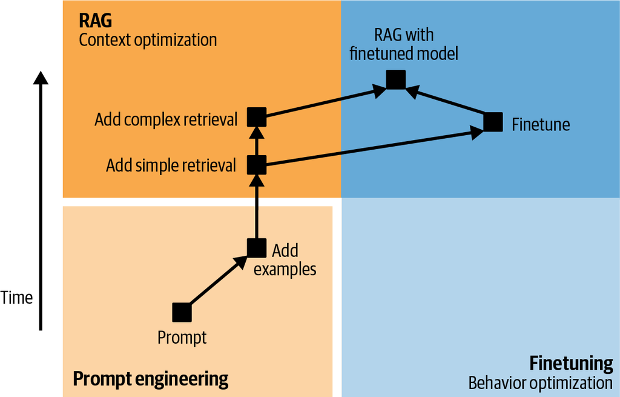

Fine-tuning

## Cuándo vale la pena el fine-tuning

**El fine-tuning vale la pena cuando la falla es de comportamiento y el prompt ya no alcanza. Estos son los casos típicos.**

### Forzar un formato de salida

JSON o YAML que el modelo tiene que respetar siempre, o código que compile.

### Un estilo o un tono fijo

Que responda siempre con la voz, el largo y la estructura del producto.

### Una tarea poco vista

Algo que el modelo general casi no vio, como un dialecto de SQL poco común.

### Un modelo chico

Que un modelo chico imite a uno grande en una tarea (destilación): más barato y más rápido.

### Cuándo no

Si al modelo le faltan datos, es un caso de RAG. Además, el ajuste puede empeorar otras tareas, y un modelo base nuevo puede superar al ajustado.

**Fuente**: [Huyen, 2025 (AI Engineering)](https://github.com/chiphuyen/aie-book/blob/main/chapter-summaries.md) · [Bagerbach, notas de AI Engineering](https://bagerbach.com/books/ai-engineering/)

Fine-tuning

## Fine-tuning en la nube

**A septiembre de 2026, Azure y Google Cloud ofrecen fine-tuning administrado a usuarios nuevos, y OpenAI cierra su plataforma. En todas el recorrido es el mismo: se suben ejemplos en JSONL, se lanza un trabajo y sale un modelo propio para desplegar.**

PlataformaModelos que se pueden ajustarMétodos

OpenAI (cerrada a usuarios nuevos)gpt-4.1, gpt-4.1-mini y gpt-4.1-nano; o4-miniSFT y DPO; RFT solo en o4-mini

Azure FoundryLos de OpenAI más gpt-4o, gpt-4o-mini y gpt-5; Llama, Qwen, Ministral y gpt-ossSFT, DPO o RFT según el modelo, con LoRA

Google Cloud: GeminiGemini 3.5 Flash, 3.1 Flash-Lite y la familia 2.5SFT con adaptadores

Google Cloud: modelos abiertosGemma 3 y 4, Qwen 3, Llama 3 y 4, GLMSFT completo o LoRA según el modelo; destilación

**Fuente**: [OpenAI, docs de optimización de modelos](https://developers.openai.com/api/docs/guides/model-optimization) · [Microsoft, docs de fine-tuning en Azure Foundry](https://learn.microsoft.com/en-us/azure/foundry/openai/how-to/fine-tuning) · [Google Cloud, docs de tuning de Gemini](https://docs.cloud.google.com/gemini-enterprise-agent-platform/models/tuning/supervised-tuning)

Fine-tuning

## Fine-tuning local: el recorrido

**Con un modelo de pesos abiertos, el fine-tuning corre en una GPU propia o en un notebook de Colab. Las librerías de Hugging Face (TRL y PEFT) o Unsloth resuelven el entrenamiento.**

- **Un ejemplo completo**: La guía de Google ajusta Gemma 4 E2B cargado en 4 bits (NF4), con LoRA de rango 16, para traducir preguntas a SQL. Enmascara todo lo que viene antes de la respuesta.

**Fuente**: [Hugging Face, docs de TRL SFTTrainer](https://huggingface.co/docs/trl/sft_trainer) · [Unsloth, guía de fine-tuning](https://unsloth.ai/docs/get-started/fine-tuning-llms-guide) · [Google, guía de QLoRA con Gemma](https://ai.google.dev/gemma/docs/core/huggingface_text_finetune_qlora)

[figure not shown]

Fine-tuning

## Qué pedirle a los datos

**Un dataset chico y parecido a la tarea le gana a uno grande y genérico.**

### Formato

JSONL con conversaciones (`messages`, con roles system, user y assistant) o con pares `prompt` y `completion`. TRL, Google Cloud y Azure aceptan estas formas.

### Cantidad

Azure exige al menos 10 ejemplos y recomienda empezar con 50 bien armados; como buena práctica sugiere cientos o miles.

### Adecuación

En el paper de QLoRA, 9.000 ejemplos de OASST1 superan a 450.000 de FLAN v2 como chatbot.

### Curado

En LIMA, 1.000 ejemplos curados alcanzan un modelo competitivo.

**Fuente**: [Microsoft, docs de fine-tuning en Azure Foundry](https://learn.microsoft.com/en-us/azure/foundry/openai/how-to/fine-tuning) · [Dettmers et al., 2023](https://arxiv.org/abs/2305.14314) · [Bagerbach, notas de AI Engineering](https://bagerbach.com/books/ai-engineering/)

Fine-tuning

## Fine-tuning: un ejemplo

**Notebook** [Fine-tuning: ejemplo en DataCamp DataLab](https://www.datacamp.com/datalab/w/6e85b332-8365-42e3-9cd1-c0616eeac8d2/edit)

01Introducción 02Pre-training 03Supervised Fine-Tuning 04Reinforcement Learning from Human Feedback 05Razonamiento con RL 06Herramientas 07Fine-tuning 08Conclusiones

08

Conclusiones

Conclusiones

## Dónde nace cada comportamiento

**Cada comportamiento que se ve en un LLM viene de una etapa concreta del entrenamiento, y cada etapa tiene su arreglo.**

Lo que se observaEtapa donde naceQué se puede hacer

Repite los sesgos y los huecos de sus datosDatos de pre-trainingCurar los datos; post-training para negarse

Completa en vez de responderPre-training sin SFTUsar un modelo con post-training

Sigue el formato y el tono pedidosSFTDemostraciones de calidad

Prefiere unas respuestas a otrasRLHF o DPODatos de comparación

Llama herramientas: calcula, busca, usa MCPSFT con las llamadas en el texto; preferencias y RL para encadenarlas en tareas de varios pasosDefiniciones claras de cada herramienta (MCP) y un agente que las ejecute

Razona antes de responder, y más cuanto más difícil es el problemaRL con verificadoresUsar un modelo de razonamiento en tareas cuya respuesta se puede comprobar

No responde en la forma que necesita el productoTodo lo anteriorPrompt y RAG; si no alcanza, fine-tuning con LoRA o QLoRA, en la nube (Azure, Google) o local

**Fuente**: Las de cada sección.